# AI_CA4_810199576

## MohammadHoseinAghili 810199576

**1-Check the data set**

```python
import pandas as pd
import math
```

```python
df = pd.read_csv('house_data.csv')

print(df.info())

print(df.describe())
```

```
<class 'pandas.core.frame.DataFrame'>
RangeIndex: 21613 entries, 0 to 21612
Data columns (total 27 columns):
 #   Column         Non-Null Count  Dtype
---  ------         --------------  -----
 0   Unnamed: 0.2   21613 non-null  int64
 1   Unnamed: 0.1   21613 non-null  int64
 2   Unnamed: 0     21613 non-null  int64
 3   id             21613 non-null  int64
 4   date           21613 non-null  object
 5   price          21613 non-null  float64
 6   bedrooms       21613 non-null  int64
 7   bathrooms      21613 non-null  float64
 8   sqft_living    18528 non-null  float64
 9   sqft_lot       21613 non-null  int64
 10  floors         18530 non-null  float64
 11  waterfront     21613 non-null  int64
 12  view           21613 non-null  int64
 13  condition      21613 non-null  int64
 14  grade          21613 non-null  int64
 15  sqft_above     21613 non-null  int64
 16  sqft_basement  21184 non-null  float64
 17  yr_built       18531 non-null  float64
 18  yr_renovated   21613 non-null  int64
 19  zipcode        21613 non-null  int64
 20  lat            21613 non-null  float64
 21  long           21613 non-null  float64
 22  sqft_living15  21613 non-null  int64
 23  sqft_lot15     21613 non-null  int64
 24  location       21613 non-null  object
 25  style          21613 non-null  object
 26  house_age      21613 non-null  int64
dtypes: float64(8), int64(16), object(3)
memory usage: 4.5+ MB
None
       Unnamed: 0.2  Unnamed: 0.1   Unnamed: 0            id         price  \
count   21613.00000   21613.00000  21613.00000  2.161300e+04  2.161300e+04
mean    10806.00000   10806.00000  10806.00000  4.580302e+09  5.401822e+05
std      6239.28002    6239.28002   6239.28002  2.876566e+09  3.673622e+05
min         0.00000       0.00000      0.00000  1.000102e+06  7.500000e+04
```

[output cut: 31 more lines]

```
50%    98065.000000     47.571800   -122.230000    1840.000000    7620.000000
75%    98118.000000     47.678000   -122.125000    2360.000000   10083.000000
max    98199.000000     47.777600   -121.315000    6210.000000  871200.000000

          house_age
count  21613.000000
mean      50.994864
std       29.373411
min        7.000000
25%       25.000000
50%       47.000000
75%       71.000000
max      122.000000

[8 rows x 24 columns]
```

```python
missing_values = df.isnull().sum()

# print(missing_values)

missing_proportion = missing_values / len(df)

missing_data = pd.DataFrame({'Missing Values': missing_values, 'Missing Proportion': missing_proportion})
missing_data.sort_values(by='Missing Values', ascending=False, inplace=True)

print(missing_data)
```

```
               Missing Values  Missing Proportion
sqft_living              3085            0.142738
floors                   3083            0.142646
yr_built                 3082            0.142599
sqft_basement             429            0.019849
Unnamed: 0.2                0            0.000000
sqft_above                  0            0.000000
style                       0            0.000000
location                    0            0.000000
sqft_lot15                  0            0.000000
sqft_living15               0            0.000000
long                        0            0.000000
lat                         0            0.000000
zipcode                     0            0.000000
yr_renovated                0            0.000000
condition                   0            0.000000
grade                       0            0.000000
Unnamed: 0.1                0            0.000000
view                        0            0.000000
waterfront                  0            0.000000
sqft_lot                    0            0.000000
bathrooms                   0            0.000000
bedrooms                    0            0.000000
price                       0            0.000000
date                        0            0.000000
id                          0            0.000000
Unnamed: 0                  0            0.000000
house_age                   0            0.000000
```

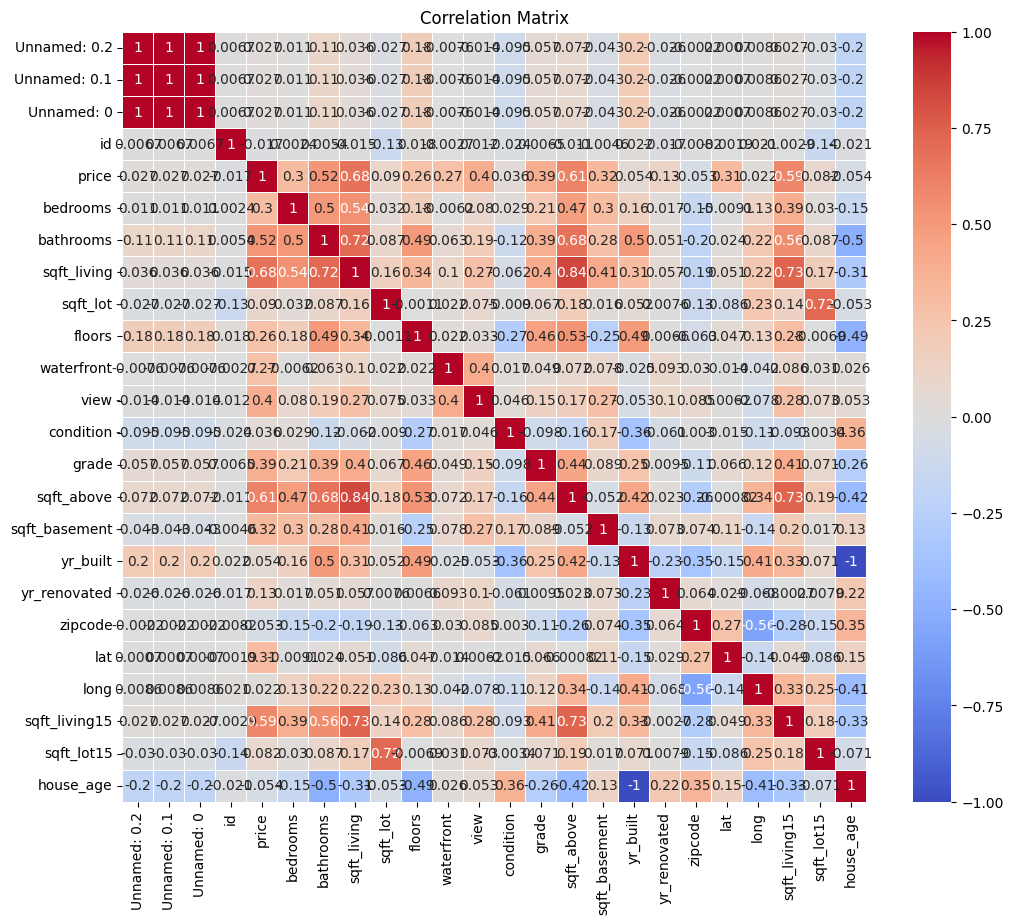

```python
import seaborn as sns
import matplotlib.pyplot as plt

# Calculate the correlation matrix
correlation_matrix = df.corr()

# Create a heatmap of the correlation matrix
plt.figure(figsize=(12, 10))
sns.heatmap(correlation_matrix, annot=True, cmap='coolwarm', linewidths=0.5)
plt.title('Correlation Matrix')
plt.show()
```

according the above Heat Map darker colors show stronger correlations between features so sqft_living, sqft above, sqft_living15 has more correlation in price value respectively.

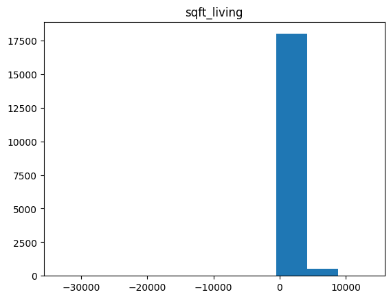

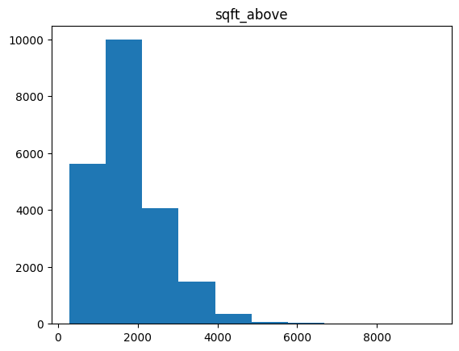

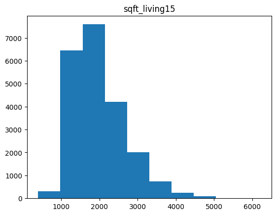

```python
cols = ["sqft_living","sqft_above","sqft_living15"]
for column in cols:
    data = df[column]
    plt.figure()
    plt.hist(data)
    plt.title(column)
    plt.show()
```

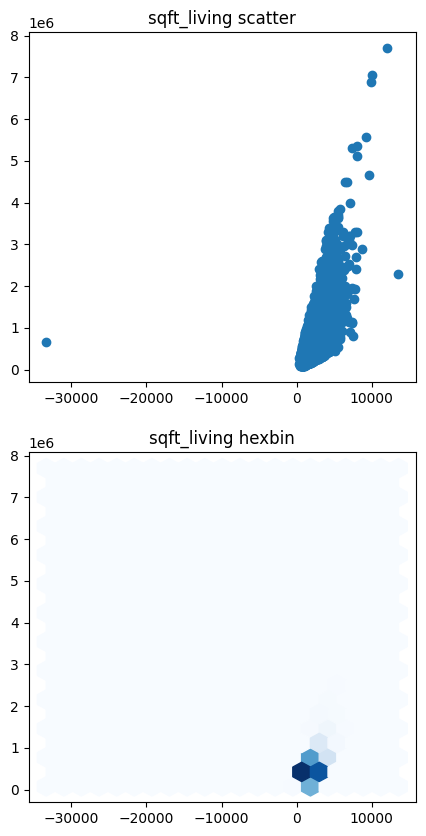

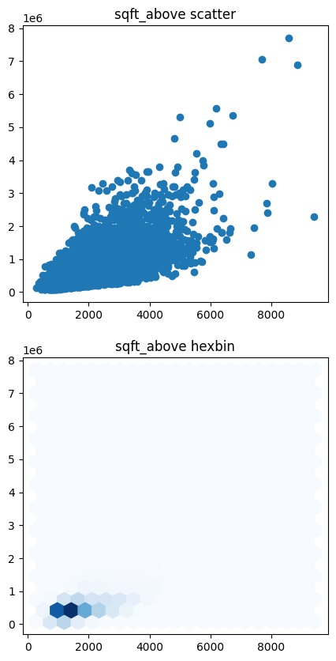

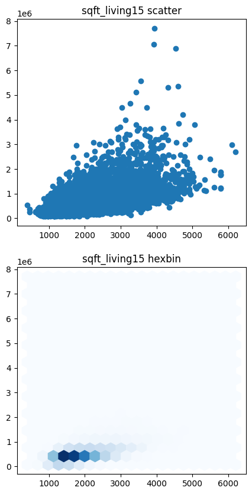

```python
for column in cols:
    fig, axes = plt.subplots(nrows=2, figsize=(5, 10))
    axes[0].scatter(df[column], df['price'])
    axes[0].set_title(f"{column} scatter")
    axes[1].hexbin(df[column], df['price'], gridsize=20, cmap='Blues')
    axes[1].set_title(f"{column} hexbin")
```

**2-Preprocessing the Data**

four other ways to solve missing data problem:

1- Forward or backward filling: Missing values are filled using the previous or next available value in the column, respectively. This method assumes a temporal or sequential order in the data.

2- Interpolation: Missing values are estimated based on the values of neighboring data points using interpolation techniques such as linear interpolation or spline interpolation.

3- Machine learning-based imputation: Missing values are predicted using machine learning algorithms by treating the column with missing values as the target variable and using the other features as predictors.

4- Multiple imputation: Multiple imputation involves creating multiple imputed datasets and analyzing them together to account for the uncertainty introduced by imputation. It provides more robust estimates compared to single imputation methods.

# --------------------------------------------------------------------------------

For numerical features, you can fill the missing values with the mean, median, or mode of the respective column using the fillna() function:

```python
df['sqft_living'].fillna(df['sqft_living'].mean(), inplace=True)
df['floors'].fillna(df['floors'].median(), inplace=True)
df['yr_built'].fillna(df['yr_built'].mode()[0], inplace=True)
```

```python
df['sqft_basement'].fillna(df['sqft_basement'].mode()[0], inplace=True)
```

```python
df.describe()
```

|  | Unnamed: 0.2 | Unnamed: 0.1 | Unnamed: 0 | id | price | bedrooms | bathrooms | sqft_living | sqft_lot | floors | ... | sqft_above | sqft_basement | yr_built | yr_renovated | zipcode | lat | long | sqft_living15 | sqft_lot15 | house_age |
| --- | --- | --- | --- | --- | --- | --- | --- | --- | --- | --- | --- | --- | --- | --- | --- | --- | --- | --- | --- | --- | --- |
| count | 21613.00000 | 21613.00000 | 21613.00000 | 2.161300e+04 | 2.161300e+04 | 21613.000000 | 21613.000000 | 21613.000000 | 2.161300e+04 | 21613.000000 | ... | 21613.000000 | 21613.000000 | 21613.000000 | 21613.000000 | 21613.000000 | 21613.000000 | 21613.000000 | 21613.000000 | 21613.000000 | 21613.000000 |
| mean | 10806.00000 | 10806.00000 | 10806.00000 | 4.580302e+09 | 5.401822e+05 | 3.367464 | 2.111900 | 2077.569031 | 1.510697e+04 | 1.493916 | ... | 1788.390691 | 286.322722 | 1977.043215 | 84.402258 | 98077.939805 | 47.560053 | -122.213896 | 1986.552492 | 12768.455652 | 50.994864 |
| std | 6239.28002 | 6239.28002 | 6239.28002 | 2.876566e+09 | 3.673622e+05 | 0.943028 | 0.780697 | 883.264047 | 4.142051e+04 | 0.498677 | ... | 828.090978 | 440.112814 | 31.122118 | 401.679240 | 53.505026 | 0.138564 | 0.140828 | 685.391304 | 27304.179631 | 29.373411 |
| min | 0.00000 | 0.00000 | 0.00000 | 1.000102e+06 | 7.500000e+04 | -5.000000 | -5.000000 | -33323.000000 | 5.200000e+02 | 1.000000 | ... | 290.000000 | 0.000000 | 1900.000000 | 0.000000 | 98001.000000 | 47.155900 | -122.519000 | 399.000000 | 651.000000 | 7.000000 |
| 25% | 5403.00000 | 5403.00000 | 5403.00000 | 2.123049e+09 | 3.219500e+05 | 3.000000 | 1.750000 | 1500.000000 | 5.040000e+03 | 1.000000 | ... | 1190.000000 | 0.000000 | 1955.000000 | 0.000000 | 98033.000000 | 47.471000 | -122.328000 | 1490.000000 | 5100.000000 | 25.000000 |
| 50% | 10806.00000 | 10806.00000 | 10806.00000 | 3.904930e+09 | 4.500000e+05 | 3.000000 | 2.250000 | 2077.569031 | 7.618000e+03 | 1.500000 | ... | 1560.000000 | 0.000000 | 1981.000000 | 0.000000 | 98065.000000 | 47.571800 | -122.230000 | 1840.000000 | 7620.000000 | 47.000000 |
| 75% | 16209.00000 | 16209.00000 | 16209.00000 | 7.308900e+09 | 6.450000e+05 | 4.000000 | 2.500000 | 2420.000000 | 1.068800e+04 | 2.000000 | ... | 2210.000000 | 550.000000 | 2006.000000 | 0.000000 | 98118.000000 | 47.678000 | -122.125000 | 2360.000000 | 10083.000000 | 71.000000 |
| max | 21612.00000 | 21612.00000 | 21612.00000 | 9.900000e+09 | 7.700000e+06 | 33.000000 | 8.000000 | 13540.000000 | 1.651359e+06 | 3.500000 | ... | 9410.000000 | 4820.000000 | 2015.000000 | 2015.000000 | 98199.000000 | 47.777600 | -121.315000 | 6210.000000 | 871200.000000 | 122.000000 |

8 rows × 24 columns

normalize and standardize is to bring them to a similar scale or range. This process is beneficial in machine learning projects for the following reasons:

- Improved model performance: Standardizing or normalizing numerical features can help improve the performance of many machine learning algorithms. Some algorithms, such as gradient descent-based optimization algorithms, converge faster when the features are on a similar scale. Additionally, it can help prevent features with larger values from dominating the learning process.

-Equal importance to features: Standardizing or normalizing features ensures that each feature contributes equally to the model. When features have different scales, the ones with larger values can have a disproportionate influence on the model's predictions.

-Interpretability and comparability: Standardizing or normalizing features make them more interpretable and comparable. It eliminates the differences in units and scales, allowing for a more meaningful comparison between features.

(resource :net)

# -------------------------------------------------------------------------------

in this project To normalize the numerical features in our dataset, we can use various techniques such as Min-Max scaling. Here's we use min-max:

```python
from sklearn.preprocessing import MinMaxScaler

# Select the numerical features to be normalized
numerical_features = ['Unnamed: 0.2', 'Unnamed: 0.1', 'Unnamed: 0', 'id',
                      'bedrooms', 'bathrooms', 'sqft_living', 'sqft_lot', 'floors',
                      'waterfront', 'view', 'condition', 'grade', 'sqft_above',
                      'sqft_basement', 'yr_built', 'yr_renovated', 'zipcode',
                      'lat', 'long', 'sqft_living15', 'sqft_lot15', 'house_age']

# Create a MinMaxScaler object
scaler = MinMaxScaler()

# Fit and transform the selected numerical features
df[numerical_features] = scaler.fit_transform(df[numerical_features])
# df = df.drop(['price'], axis=1)
```

we can remove first 4 coloms:

```python
df = df.drop(['Unnamed: 0.2', 'Unnamed: 0.1', 'Unnamed: 0' ,'id'], axis=1)
```

```python
df.describe()
```

|  | price | bedrooms | bathrooms | sqft_living | sqft_lot | floors | waterfront | view | condition | grade | sqft_above | sqft_basement | yr_built | yr_renovated | zipcode | lat | long | sqft_living15 | sqft_lot15 | house_age |
| --- | --- | --- | --- | --- | --- | --- | --- | --- | --- | --- | --- | --- | --- | --- | --- | --- | --- | --- | --- | --- |
| count | 2.161300e+04 | 21613.000000 | 21613.000000 | 21613.000000 | 21613.000000 | 21613.000000 | 21613.000000 | 21613.000000 | 21613.000000 | 21613.000000 | 21613.000000 | 21613.000000 | 21613.000000 | 21613.000000 | 21613.000000 | 21613.000000 | 21613.000000 | 21613.000000 | 21613.000000 | 21613.000000 |
| mean | 5.401822e+05 | 0.220196 | 0.547069 | 0.755406 | 0.008836 | 0.197566 | 0.007542 | 0.058576 | 0.602357 | 0.978323 | 0.164297 | 0.059403 | 0.669941 | 0.041887 | 0.388585 | 0.650076 | 0.253408 | 0.273198 | 0.013919 | 0.382564 |
| std | 3.673622e+05 | 0.024817 | 0.060054 | 0.018848 | 0.025091 | 0.199471 | 0.086517 | 0.191579 | 0.162686 | 0.008181 | 0.090799 | 0.091310 | 0.270627 | 0.199345 | 0.270227 | 0.222879 | 0.116967 | 0.117947 | 0.031364 | 0.255421 |
| min | 7.500000e+04 | 0.000000 | 0.000000 | 0.000000 | 0.000000 | 0.000000 | 0.000000 | 0.000000 | 0.000000 | 0.000000 | 0.000000 | 0.000000 | 0.000000 | 0.000000 | 0.000000 | 0.000000 | 0.000000 | 0.000000 | 0.000000 | 0.000000 |
| 25% | 3.219500e+05 | 0.210526 | 0.519231 | 0.743081 | 0.002738 | 0.000000 | 0.000000 | 0.000000 | 0.500000 | 0.975709 | 0.098684 | 0.000000 | 0.478261 | 0.000000 | 0.161616 | 0.506836 | 0.158638 | 0.187747 | 0.005111 | 0.156522 |
| 50% | 4.500000e+05 | 0.210526 | 0.557692 | 0.755406 | 0.004300 | 0.200000 | 0.000000 | 0.000000 | 0.500000 | 0.975709 | 0.139254 | 0.000000 | 0.704348 | 0.000000 | 0.323232 | 0.668972 | 0.240033 | 0.247978 | 0.008005 | 0.347826 |
| 75% | 6.450000e+05 | 0.236842 | 0.576923 | 0.762713 | 0.006159 | 0.400000 | 0.000000 | 0.000000 | 0.750000 | 0.979757 | 0.210526 | 0.114108 | 0.921739 | 0.000000 | 0.590909 | 0.839794 | 0.327243 | 0.337463 | 0.010835 | 0.556522 |
| max | 7.700000e+06 | 1.000000 | 1.000000 | 1.000000 | 1.000000 | 1.000000 | 1.000000 | 1.000000 | 1.000000 | 1.000000 | 1.000000 | 1.000000 | 1.000000 | 1.000000 | 1.000000 | 1.000000 | 1.000000 | 1.000000 | 1.000000 | 1.000000 |

**To train and evaluate a learning model, it is common to divide the data into two categories: a training set and a test set. The ratio of this division can vary depending on the size of the dataset and the specific requirements of the task at hand. However, a common practice is to allocate around 70-80% of the data to the training set and the remaining 20-30% to the test set.**

Several methods:

- Holdout Method: This is the simplest approach, where the dataset is randomly split into a training set and a test set based on the desired ratio. The data points are randomly assigned to either the training set or the test set, ensuring that each set represents a proportionate distribution of the target variable.
- Cross-Validation: Cross-validation is a more robust technique that involves splitting the data into multiple subsets, often referred to as "folds." The model is trained and evaluated multiple times, each time using a different combination of folds as the training and test sets. Common cross-validation methods include k-fold cross-validation and stratified k-fold cross-validation.
- Time-Based Split: If the dataset has a temporal component, such as time-series data, it is common to split the data based on a specific time point. Typically, the earlier portion of the data is used for training, and the later portion is used for testing. This ensures that the model is trained on past data and evaluated on future data, simulating real-world scenarios.

# ---------------------------------------------------------------------------

The purpose of the validation set is to fine-tune the model's hyperparameters and assess its performance during the training process.

The validation set serves as an intermediate step between the training set and the final evaluation on the test set. It helps in evaluating the model's performance on unseen data and making adjustments to improve its generalization ability.

```python
from sklearn.model_selection import train_test_split

x = df.drop('price', axis=1)
y = df['price']

train_ds, test_ds , train_lable, test_lable = train_test_split(x, y, test_size=0.3, random_state=1)
```

```python
# print("train: \n")
# train_lable.describe()
print(train_lable)
# print("test: \n")
# test_lable.describe()
```

```
2060      272500.0
11759     206000.0
8274       82000.0
21272     415500.0
14328     920000.0
           ...
10955     571000.0
17289    1350000.0
5192      650000.0
12172     437000.0
235      1030000.0
Name: price, Length: 15129, dtype: float64
```

# Linear Regression

Main form of simple linear regression function: $$f(x) = \alpha x + \beta$$

- step 1: Compute RSS of the training data

$$ RSS = \Sigma (y_i - (\hat{\beta} + \hat{\alpha} * x_i) )^2 $$

- step 2: Compute the derivatives of the RSS function in term of $\underline{\alpha}$ and $\underline{\beta}$, and set them equal to 0 to find the desired parameters

$$ \frac{\partial RSS}{\partial \beta} = \Sigma (-f(x_i) + \hat{\beta} + \hat{\alpha} * x_i) = 0$$$$ \to \hat{\beta} = \hat{y} - \hat{\alpha} \hat{x} \to (1)$$$$ \frac{\partial RSS}{\partial \alpha} = \Sigma (-2 x_i y_i + 2 \hat{\beta} x_i + 2\hat{\alpha} x_i ^ 2) = 0 \to (2)$$$$ (1) , (2) \to \hat{\alpha} = \frac{\Sigma{(x_i - \hat{x})(y_i - \hat{y})}}{\Sigma{(x_i - \hat{x})^2}} $$

$$ \hat{\beta} = \hat{y} - \hat{\alpha} \hat{x}$$

# -------------------------------------------------------------------------------

The RSS is a measure of the difference between the predicted values and the actual values in the training data.

By calculating α̂ and β̂ using these formulas, we can obtain the optimal values that minimize the RSS and provide the best fit line for the given training data.

Based on the formula above, complete this function to compute the parameters of a simple linear regression

```python
def simple_linear_regression(input_feature, output):
    # compute the sum of input_feature and output
    sum_x = sum(input_feature)
    sum_y = sum(output)

   # compute the product of the output and the input_feature and its sum
    sum_xy = sum([x * y for x, y in zip(input_feature, output)])

    # compute the squared value of the input_feature and its sum
    sum_x_squared = sum([x ** 2 for x in input_feature])


    n = len(input_feature)
    # use the formula for the slope

    # use the formula for the intercept
    slope = (sum_xy - (sum_x * sum_y) / n) / (sum_x_squared - (sum_x ** 2) / n)
    intercept = (sum_y - slope * sum_x) / n

    #return (intercept, slope)
    return intercept, slope
```

Now complete this function to predict the value of given data based on the calculated intercept and slope

```python
def get_regression_predictions(input_feature, intercept, slope):
    #TODO
    # Calculate the predicted values:
    predicted_values = intercept + slope * input_feature

    return predicted_values
```

Now that we have a model and can make predictions let's evaluate our model using Root Mean Square Error (RSME). RMSE is the square root of the mean of the squared differences between the residuals and the residuals is just a fancy word for the difference between the predicted output and the true output.

Complete the following function to compute the RSME of a simple linear regression model given the input_feature, output, intercept and slope:

```python
import numpy as np

def get_root_mean_square_error(predicted_values, output):
    # TO DO:
    # compute the residuals
    residuals = predicted_values - output

   # square the residuals and add them up
    squared_residuals = np.square(residuals)
    sum_squared_residuals = np.sum(squared_residuals)

    # find the mean of the above phrase
    mean_squared_residuals = sum_squared_residuals / len(predicted_values)

    # Calculate the root
    rmse = np.sqrt(mean_squared_residuals)

    return rmse
```

AS you might guessed, the RMSE has no bound and it is not easy to find out the percentage of fitting the model into data with it. instead, we use R2 score. The R2 score is calculated by comparing the sum of the squared differences between the actual and predicted values of the dependent variable to the total sum of squared differences between the actual and mean values of the dependent variable. Matematically, the R2 score formula is shown as follows:

$$R^2 = 1 - \frac{SSres}{SStot} = 1 - \frac{\sum_{i=1}^{n} (y_{i,true} - y_{i,pred})^2}{\sum_{i=1}^{n} (y_{i,true} - \bar{y}_{true})^2} $$

In this step, complete the following function to calculate the R2 score of a given input_feature, output, intercept, and slope:

```python
def get_r2_score(predicted_values, output):
 # TO DO:

    # then compute the residuals (since we are squaring it doesn't matter which order you subtract)
    residuals = output - predicted_values

    # square the residuals and add them upSSres
    ss_res = np.sum(np.square(residuals))

    # compute the SStot
    mean_output = np.mean(output)
    ss_tot = np.sum(np.square(output - mean_output))


    # compute the R2 score value
    r2_score = 1 - (ss_res / ss_tot)

    return r2_score
```

Now calculate the fitness of the model and explain the outputs

```python
designated_feature_list = ['sqft_living' , 'yr_built' , 'grade' , 'zipcode']


for feature in designated_feature_list:
    # Get the input feature and output for the current feature
    train_input_feature = train_ds[feature]
    train_output = train_lable

    test_input_feature = test_ds[feature]
    test_output = test_lable

    # Perform simple linear regression
    intercept, slope = simple_linear_regression(train_input_feature, train_output)

    # Get the predicted values
    test_predicted_values = get_regression_predictions(test_input_feature, intercept, slope)

    # Calculate R2 score

    test_r2_score = get_r2_score(test_predicted_values, test_output)

    # Calculate RMSE
    test_rmse = get_root_mean_square_error(test_predicted_values, test_output)

    # Explain the outputs
    print(f"Feature: {feature}")
    print("Test Data:")
    print(f"R2 Score: {test_r2_score}")
    print(f"RMSE: {test_rmse}")
    print("-----------------------")
```

```
Feature: sqft_living
Test Data:
R2 Score: 0.44717185635081724
RMSE: 293894.47850014165
-----------------------
Feature: yr_built
Test Data:
R2 Score: 0.0016945437311692846
RMSE: 394937.2312586115
-----------------------
Feature: grade
Test Data:
R2 Score: -1.926306901935991
RMSE: 676170.6108430476
-----------------------
Feature: zipcode
Test Data:
R2 Score: 0.003210798226970346
RMSE: 394637.1963846447
-----------------------
```

```python
for feature in cols:

    train_input_feature = train_ds[feature]
    train_output = train_lable

    test_input_feature = test_ds[feature]
    test_output = test_lable

    intercept, slope = simple_linear_regression(train_input_feature, train_output)

    test_predicted_values = get_regression_predictions(test_input_feature, intercept, slope)

    predictdf = pd.DataFrame({'predicted': test_predicted_values, 'real': test_output})
    print(f"Feature: {feature}")
    print("predicted Test Data:\n")
    print(predictdf)
```

```
Feature: sqft_living
predicted Test Data:

          predicted       real
15544  5.387256e+05   459000.0
17454  5.387256e+05   445000.0
21548  6.102147e+05  1060000.0
3427   5.857682e+05   732350.0
8809   3.804179e+05   235000.0
...             ...        ...
14866  5.387256e+05   394500.0
4903   5.387256e+05   259950.0
16080  3.437483e+05   230000.0
15668  1.294715e+06  1680000.0
18802  5.387256e+05   293000.0

[6484 rows x 2 columns]
Feature: sqft_above
predicted Test Data:

           predicted       real
15544  799694.836953   459000.0
17454  413697.531996   445000.0
21548  690155.061222  1060000.0
3427   664074.162238   732350.0
8809   335454.835045   235000.0
...              ...        ...
14866  854986.342798   394500.0
4903   395440.902707   259950.0
16080  291117.306773   230000.0
15668  990085.399533  1680000.0
18802  919666.972277   293000.0

[6484 rows x 2 columns]
Feature: sqft_living15
predicted Test Data:

          predicted       real
15544  8.154573e+05   459000.0
17454  4.274107e+05   445000.0
21548  1.106492e+06  1060000.0
3427   6.790347e+05   732350.0
8809   3.273674e+05   235000.0
...             ...        ...
14866  7.142014e+05   394500.0
4903   4.956220e+05   259950.0
16080  4.395372e+05   230000.0
15668  8.518367e+05  1680000.0
18802  4.213475e+05   293000.0

[6484 rows x 2 columns]
```

R2 Score:

RMSE :

- RMSE is a popular evaluation metric that calculates the average deviation

between the predicted values and the actual values in the original units of the dependent variable. It measures the square root of the average squared differences between the predicted and actual values. RMSE provides a measure of the absolute fit of the model to the data, where lower values indicate better model performance. RMSE is useful for understanding the magnitude of errors in the predictions.

MSE :

- MSE is another evaluation metric that calculates the average squared

differences between the predicted values and the actual values. It is obtained by summing up the squared differences and dividing by the number of samples. MSE is similar to RMSE but does not involve taking the square root. Like RMSE, lower MSE values indicate better model performance.

RSS :

- RSS is a measure of the total squared differences between the actual values

and the predicted values. It quantifies the residual errors of the model. RSS is computed by summing up the squared residuals (the differences between the actual and predicted values) for each data point. In linear regression, the goal is to minimize the RSS, as a lower RSS indicates a better fit of the model to the data.

**These evaluation metrics provide different perspectives on the performance of linear regression models. R2 score indicates the proportion of variability explained by the model, while RMSE, MSE, and RSS provide measures of the accuracy and goodness-of-fit of the predictions. It's important to consider these metrics together to gain a comprehensive understanding of the model's performance**

# -------------------------------------------------------------------------------

**Base on above result the "sqft_living" feature seems to be the most informative among the features tested, as it exhibits a relatively higher R2 score and a lower RMSE compared to the other features. On the other hand, the "yr_built," "grade," and "zipcode" features show poor performance with very low R2 scores and high RMSE values, indicating that they are not effective predictors in this model.**

# phas 2:

```python
median_price = df['price'].median()
df['price_level'] = df['price'].apply(lambda x: 'HIGH' if x > median_price else 'LOW')
# df.head(500)
```

```python
import pandas as pd


from sklearn.preprocessing import LabelEncoder

label_encoder = LabelEncoder()

cols_to_encode =['date','location','style','price_level' ]
for col in cols_to_encode:
    df[col] = label_encoder.fit_transform(df[col])


X = df.drop(['price_level'], axis=1)
y = df['price_level']

X_train, X_test, y_train, y_test = train_test_split(X, y, test_size=0.2, random_state=42)
# X_train.head(50)
```

```python
from sklearn.linear_model import LogisticRegression
from sklearn.metrics import accuracy_score

# Create and fit the Logistic Regression model
logistic_regression = LogisticRegression()
logistic_regression.fit(X_train, y_train)

# Make predictions on the test set
logistic_regression_predictions = logistic_regression.predict(X_test)


# Calculate accuracy
logistic_regression_accuracy = accuracy_score(y_test, logistic_regression_predictions)

print(f'Accuracy: {logistic_regression_accuracy}')
```

```
Accuracy: 0.6997455470737913
```

```python
from sklearn.neighbors import KNeighborsClassifier

# Create and fit the KNN model
knn = KNeighborsClassifier()
knn.fit(X_train, y_train)

# Make predictions on the test set
knn_predictions = knn.predict(X_test)

# Calculate accuracy
knn_accuracy = accuracy_score(y_test, knn_predictions)

print(f'Accuracy: {knn_accuracy}')
```

```
Accuracy: 0.9997686791579922
```

```python
from sklearn.tree import DecisionTreeClassifier

# Create and fit the Decision Tree model
decision_tree = DecisionTreeClassifier()
decision_tree.fit(X_train, y_train)

# Make predictions on the test set
decision_tree_predictions = decision_tree.predict(X_test)

# Calculate accuracy
decision_tree_accuracy = accuracy_score(y_test, decision_tree_predictions)

print(f'Accuracy: {decision_tree_accuracy}')
```

```
Accuracy: 1.0
```

**Underfitting**: Underfitting refers to a situation where a model is unable to capture the underlying patterns and relationships in the data. It occurs when a model is too simple or lacks complexity to accurately represent the data. An underfit model usually has high bias and low variance. Signs of underfitting include low training and testing accuracy and poor performance on unseen data.

**Overfitting**: Overfitting occurs when a model becomes too complex and starts to memorize the training data instead of generalizing well to unseen data. It happens when a model captures noise, outliers, or random fluctuations in the training data. An overfit model usually has low bias and high variance. Signs of overfitting include high training accuracy but low testing accuracy, and large differences between training and testing performance.

Based on the provided results, it appears that overfitting did not occur in any of the models, while underfitting might have occurred in the Logistic Regression model.

# Ensemble Learning

#### Two most used meta-parameters in Random Forest models are:

1- n_estimators: This parameter determines the number of decision trees in the ensemble. Increasing the number of trees can potentially improve the model's performance, but it also increases computational complexity.

2- max_depth: This parameter sets the maximum depth of each decision tree. Increasing the maximum depth allows the trees to capture more complex relationships in the data but can also lead to overfitting.

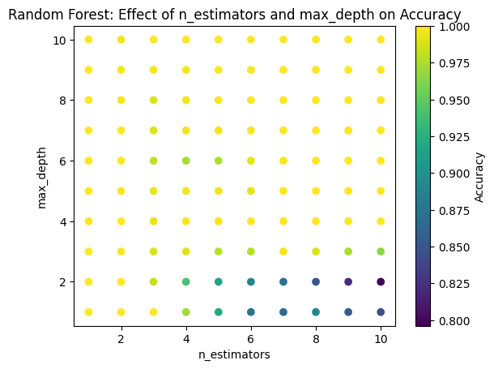

```python
from sklearn.ensemble import RandomForestClassifier
from sklearn.metrics import accuracy_score

# Initialize lists to store results
n_estimators_values = []
max_depth_values = []
accuracy_scores = []


for n_estimators in range(1, 11):
    for max_depth in range(1, 11):
        model = RandomForestClassifier(n_estimators=n_estimators, max_depth=max_depth, random_state=42)
        model.fit(X_train, y_train)
        predictions = model.predict(X_test)
        accuracy = accuracy_score(y_test, predictions)
        accuracy_scores.append(accuracy)
        n_estimators_values.append(n_estimators)
        max_depth_values.append(max_depth)

fig, ax = plt.subplots()
sc = ax.scatter(n_estimators_values, max_depth_values, c=accuracy_scores, cmap='viridis')
plt.colorbar(sc, label='Accuracy')
plt.xlabel('n_estimators')
plt.ylabel('max_depth')
plt.title('Random Forest: Effect of n_estimators and max_depth on Accuracy')
plt.show()
```